# chap4

```r
library(hexView)
```

### Bài 1

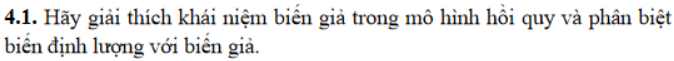

Biến giả là biến được đưa vào mô hình nhằm đánh giá tác động của một biến định tính lên biến phụ thuộc

Biến định lượng là biến số thực, trong khi biến giả nhận giá trị (0 hoặc 1)

### Bài 2

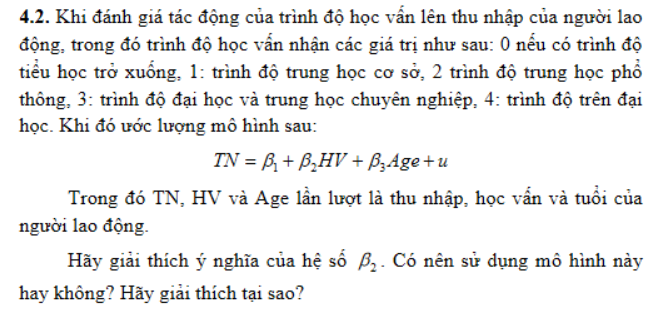

$\beta_2$ là mức chênh lệch thu nhập trung bình của những người cùng tuổi

Không nên vì mức chênh lệch là khác nhau giữa các trình độ học vấn

### Bài 3

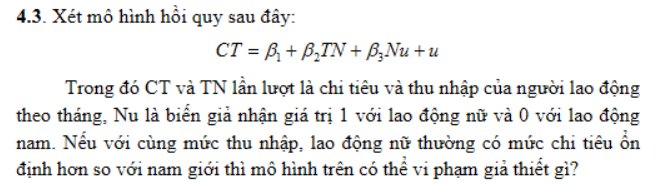

$Var(u|X_2,…,X_k)=\sigma^2$

Mà $Var(u|NU)\not = Var(u|Nam)$

Vi phạm giả thiết 3 phương sai sai số thay đổi

### Bài 4

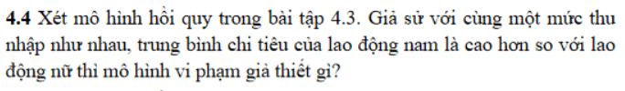

Vi phạm giả thiết 2, kỳ vọng sai số = 0

### Bài 5

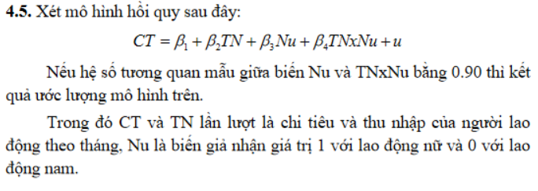

Xuất hiện hiện tượng đa cộng tuyến, sai số chuẩn bị khuếch đại lên nhiều lần

### Bài 6

```r
bai6 <- readEViews("../chap 02/ch2bt3.wf1")
```

```r
hq <- lm(data = bai6, log(WAGE)~GRADE+UNION)
summary(hq)
```

```
Call:
lm(formula = log(WAGE) ~ GRADE + UNION, data = bai6)

Residuals:
     Min       1Q   Median       3Q      Max
-0.74059 -0.24246 -0.04372  0.21430  1.66084

Coefficients:
            Estimate Std. Error t value Pr(>|t|)
(Intercept)  1.91393    0.18698  10.236  < 2e-16 ***
GRADE        0.05373    0.01522   3.529 0.000639 ***
UNION        0.19810    0.10796   1.835 0.069590 .
---
Signif. codes:  0 '***' 0.001 '**' 0.01 '*' 0.05 '.' 0.1 ' ' 1

Residual standard error: 0.4221 on 97 degrees of freedom
Multiple R-squared:  0.1492,	Adjusted R-squared:  0.1316
F-statistic: 8.502 on 2 and 97 DF,  p-value: 0.0003959
```

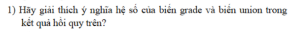

Nếu số năm đi học tăng lên 1 thì tiền lương tăng 5%

Nếu tham gia công đoàn thì lương cao hơn 19%

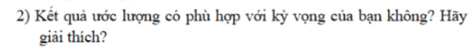

Có

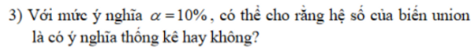

Có

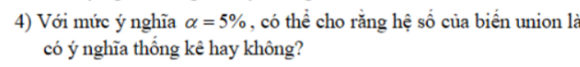

Không

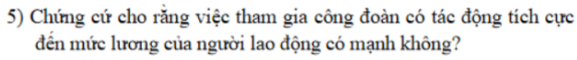

Tương đói mạnh

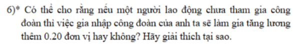

```r
library(car)
```

```r
linearHypothesis(hq, c("UNION=0.2"))
```

A anova: 2 × 6

|  | Res.Df <dbl> | RSS <dbl> | Df <dbl> | Sum of Sq <dbl> | F <dbl> | Pr(>F) <dbl> |
| --- | --- | --- | --- | --- | --- | --- |
| 1 | 98 | 17.28273 | NA | NA | NA | NA |
| 2 | 97 | 17.28268 | 1 | 5.510099e-05 | 0.0003092574 | 0.9860055 |

Có, pvalue cao

### Bài 7

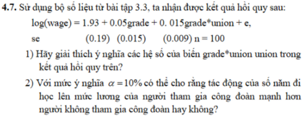

```r
summary(lm(data = bai6, log(WAGE)~GRADE + I(GRADE*UNION)))
```

```
Call:
lm(formula = log(WAGE) ~ GRADE + I(GRADE * UNION), data = bai6)

Residuals:
     Min       1Q   Median       3Q      Max
-0.74223 -0.26271 -0.03032  0.21314  1.65835

Coefficients:
                 Estimate Std. Error t value Pr(>|t|)
(Intercept)      1.926721   0.187278  10.288  < 2e-16 ***
GRADE            0.052870   0.015313   3.453 0.000824 ***
I(GRADE * UNION) 0.014828   0.008612   1.722 0.088292 .
---
Signif. codes:  0 '***' 0.001 '**' 0.01 '*' 0.05 '.' 0.1 ' ' 1

Residual standard error: 0.423 on 97 degrees of freedom
Multiple R-squared:  0.1457,	Adjusted R-squared:  0.1281
F-statistic: 8.274 on 2 and 97 DF,  p-value: 0.000481
```

1. Chênh lệch hệ số góc, tham gia công đoàn thì khi tăng 1 năm học lương cao hơn 0.015
2. Có

### Bài 8

```r
bai8 <- readEViews("ch4bt8.wf1")
bai8$TD = ifelse(bai8$EDUC < 13, 1, ifelse(16< bai8$EDUC , 3, 2))
```

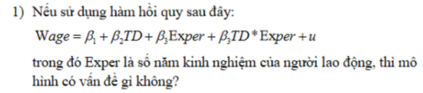

```r
summary(lm(data=bai8,WAGE~TD+TD*EXPER))
```

```
Call:
lm(formula = WAGE ~ TD + TD * EXPER, data = bai8)

Residuals:
    Min      1Q  Median      3Q     Max
-934.50 -264.94  -44.54  197.87 2014.66

Coefficients:
            Estimate Std. Error t value Pr(>|t|)
(Intercept) 3109.311     98.187  31.667  < 2e-16 ***
TD            98.089     54.596   1.797  0.07272 .
EXPER         -2.390      7.747  -0.309  0.75776
TD:EXPER      12.915      4.965   2.601  0.00944 **
---
Signif. codes:  0 '***' 0.001 '**' 0.01 '*' 0.05 '.' 0.1 ' ' 1

Residual standard error: 379.5 on 931 degrees of freedom
Multiple R-squared:  0.1222,	Adjusted R-squared:  0.1193
F-statistic: 43.18 on 3 and 931 DF,  p-value: < 2.2e-16
```

1. Biến TD ở đây phần mềm hiểu là biến định lượng, không phải biến thứ bậc

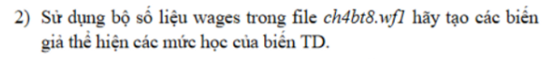

```r
bai8$muchoc = ifelse(bai8$TD == 1, "pho_thong", ifelse(bai8$TD==2 , "cao_dang", "dai_hoc"))
bai8
```

[output not shown]

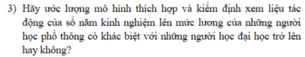

```r
summary(lm(data=bai8,WAGE~muchoc+muchoc*EXPER))
```

```
Call:
lm(formula = WAGE ~ muchoc + muchoc * EXPER, data = bai8)

Residuals:
    Min      1Q  Median      3Q     Max
-907.38 -266.99  -48.12  200.00 2005.33

Coefficients:
                      Estimate Std. Error t value Pr(>|t|)
(Intercept)           3302.577     58.922  56.050  < 2e-16 ***
muchocdai_hoc          127.906    128.513   0.995   0.3199
muchocpho_thong       -102.471     82.563  -1.241   0.2149
EXPER                   24.554      5.653   4.344 1.56e-05 ***
muchocdai_hoc:EXPER      6.891     13.888   0.496   0.6199
muchocpho_thong:EXPER  -13.708      6.976  -1.965   0.0497 *
---
Signif. codes:  0 '***' 0.001 '**' 0.01 '*' 0.05 '.' 0.1 ' ' 1

Residual standard error: 379.8 on 929 degrees of freedom
Multiple R-squared:  0.1227,	Adjusted R-squared:  0.1179
F-statistic: 25.97 on 5 and 929 DF,  p-value: < 2.2e-16
```

### Bài 9

```r
bai9 <- read.csv("bai9.csv")
```

Câu a

```r
bai9$td <- ifelse(bai9$TD=="td",1,0)
```

```r
bai9
```

A data.frame: 40 × 6

| X <int> | Date <chr> | KN <int> | NS <dbl> | TD <chr> | td <dbl> |
| --- | --- | --- | --- | --- | --- |
| 1 | 0001-01-01 | 38 | 13.73 | ktd | 0 |
| 2 | 0002-01-01 | 55 | 17.15 | td | 1 |
| 3 | 0003-01-01 | 45 | 13.63 | td | 1 |
| 4 | 0004-01-01 | 41 | 13.04 | td | 1 |
| 5 | 0005-01-01 | 42 | 13.20 | td | 1 |
| 6 | 0006-01-01 | 38 | 16.43 | ktd | 0 |
| 7 | 0007-01-01 | 39 | 13.70 | td | 1 |
| 8 | 0008-01-01 | 51 | 14.88 | td | 1 |
| 9 | 0009-01-01 | 39 | 15.19 | td | 1 |
| 10 | 0010-01-01 | 26 | 13.36 | td | 1 |
| 11 | 0011-01-01 | 55 | 16.68 | ktd | 0 |
| 12 | 0012-01-01 | 45 | 14.84 | td | 1 |
| 13 | 0013-01-01 | 35 | 14.74 | ktd | 0 |
| 14 | 0014-01-01 | 35 | 12.95 | td | 1 |
| 15 | 0015-01-01 | 36 | 12.79 | ktd | 0 |
| 16 | 0016-01-01 | 40 | 12.00 | td | 1 |
| 17 | 0017-01-01 | 38 | 15.31 | ktd | 0 |
| 18 | 0018-01-01 | 49 | 15.66 | ktd | 0 |
| 19 | 0019-01-01 | 54 | 16.12 | ktd | 0 |
| 20 | 0020-01-01 | 34 | 13.98 | td | 1 |
| 21 | 0021-01-01 | 51 | 15.58 | td | 1 |
| 22 | 0022-01-01 | 58 | 18.60 | td | 1 |
| 23 | 0023-01-01 | 23 | 11.58 | ktd | 0 |
| 24 | 0024-01-01 | 36 | 13.88 | td | 1 |
| 25 | 0025-01-01 | 40 | 13.84 | td | 1 |
| 26 | 0026-01-01 | 45 | 15.46 | ktd | 0 |
| 27 | 0027-01-01 | 51 | 14.31 | td | 1 |
| 28 | 0028-01-01 | 47 | 13.87 | td | 1 |
| 29 | 0029-01-01 | 38 | 13.51 | ktd | 0 |
| 30 | 0030-01-01 | 34 | 13.15 | td | 1 |
| 31 | 0031-01-01 | 54 | 14.94 | ktd | 0 |
| 32 | 0032-01-01 | 51 | 17.26 | ktd | 0 |
| 33 | 0033-01-01 | 45 | 15.31 | ktd | 0 |
| 34 | 0034-01-01 | 46 | 17.69 | ktd | 0 |
| 35 | 0035-01-01 | 61 | 15.63 | td | 1 |
| 36 | 0036-01-01 | 57 | 13.44 | td | 1 |
| 37 | 0037-01-01 | 57 | 17.81 | td | 1 |
| 38 | 0038-01-01 | 48 | 15.50 | td | 1 |
| 39 | 0039-01-01 | 50 | 14.58 | ktd | 0 |
| 40 | 0040-01-01 | 49 | 14.94 | td | 1 |

Câu 2

```r
hq <- lm(data=bai9, NS~KN+TD)
summary(hq)
```

```
Call:
lm(formula = NS ~ KN + TD, data = bai9)

Residuals:
    Min      1Q  Median      3Q     Max
-2.5584 -0.9012 -0.0626  0.7101  2.4780

Coefficients:
            Estimate Std. Error t value Pr(>|t|)
(Intercept)   9.7403     0.9797   9.942 5.37e-12 ***
KN            0.1237     0.0215   5.753 1.36e-06 ***
TDtd         -0.7907     0.3843  -2.058   0.0467 *
---
Signif. codes:  0 '***' 0.001 '**' 0.01 '*' 0.05 '.' 0.1 ' ' 1

Residual standard error: 1.186 on 37 degrees of freedom
Multiple R-squared:  0.4896,	Adjusted R-squared:  0.462
F-statistic: 17.74 on 2 and 37 DF,  p-value: 3.952e-06
```

Cách 2

```r
hq1 <- lm(data=bai9, NS~KN+td)
summary(hq1)
```

```
Call:
lm(formula = NS ~ KN + td, data = bai9)

Residuals:
    Min      1Q  Median      3Q     Max
-2.5584 -0.9012 -0.0626  0.7101  2.4780

Coefficients:
            Estimate Std. Error t value Pr(>|t|)
(Intercept)   9.7403     0.9797   9.942 5.37e-12 ***
KN            0.1237     0.0215   5.753 1.36e-06 ***
td           -0.7907     0.3843  -2.058   0.0467 *
---
Signif. codes:  0 '***' 0.001 '**' 0.01 '*' 0.05 '.' 0.1 ' ' 1

Residual standard error: 1.186 on 37 degrees of freedom
Multiple R-squared:  0.4896,	Adjusted R-squared:  0.462
F-statistic: 17.74 on 2 and 37 DF,  p-value: 3.952e-06
```

Câu 3

```r
linearHypothesis(hq,c("TDtd=0"))
```

A anova: 2 × 6

|  | Res.Df <dbl> | RSS <dbl> | Df <dbl> | Sum of Sq <dbl> | F <dbl> | Pr(>F) <dbl> |
| --- | --- | --- | --- | --- | --- | --- |
| 1 | 38 | 57.97922 | NA | NA | NA | NA |
| 2 | 37 | 52.02611 | 1 | 5.953111 | 4.233741 | 0.04672587 |

```r
names(bai9)
```

1. 'X'

2. 'Date'

3. 'KN'

4. 'NS'

5. 'TD'

6. 'td'

Câu 4

https://www.statology.org/chow-test-in-r/#:~:text=How%20to%20Perform%20a%20Chow%20Test%20in%20R,structural%20break%20in%20the%20data%20at%20some%20point.

```r
library(lmtest)

# Create two linear regression models
model1 <- lm(NS~KN, data = bai9[(bai9$td == 1),])
model2 <- lm(NS~KN, data = bai9[(bai9$td == 0),])
```

```r
rss1 <- sum(residuals(model1)^2)
rss2 <- sum(residuals(model2)^2)
rss <- sum(residuals(hq1)^2)
```

$$ F=\frac{[RSS-(RSS_1+RSS_2)]/k}{(RSS_1+RSS_2)/(n-2k)}\text{\textasciitilde}f_\alpha(k,n-2k) $$

```r
f<-((rss-rss1-rss2)/1)/((rss1+rss2)/(40-2*1))
f
```

0.0514861046889674

```r
f5 <- qf(0.95,1,38)
f5
```

4.09817173088084

Chưa bác bỏ $H_0$